# PROYECTO_COMBUSTIBLE

## 3.7 Visualización de datos

### 3.7.1 Histograma de las emisiones de CO2

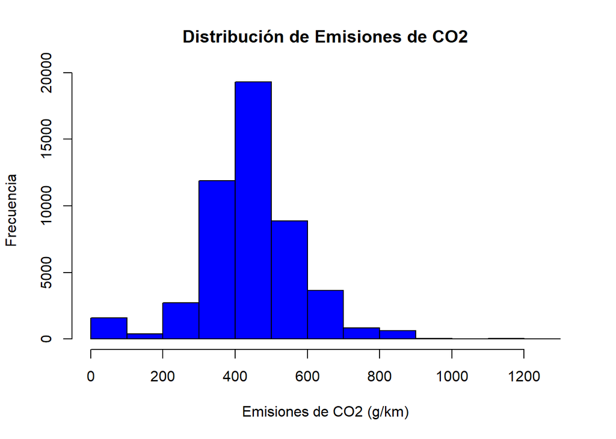

```r
hist(datos_limpios$co2TailpipeGpm,
     main = "Distribución de Emisiones de CO2",
     xlab = "Emisiones de CO2 (g/km)",
     ylab = "Frecuencia",
     col = "blue",
     border = "black")
```

> El histograma muestra la distribución de las emisiones de CO2 (g/km) de los vehículos analizados, revelando una distribución unimodal con un sesgo positivo hacia la derecha. La mayor concentración de datos se encuentra en el rango de los 400 a 500 g/km, donde se observa la frecuencia más alta, superando las 15,000 unidades. Si bien la mayoría de los vehículos se agrupan entre los 300 y 600 g/km, existe una presencia notable de valores atípicos hacia la derecha que alcanzan hasta los 1,200 g/km, lo que indica que, aunque la mayoría de los vehículos presentan niveles de emisión moderados, hay una minoría de modelos con emisiones significativamente más elevadas que impactan la dispersión total del conjunto de datos.

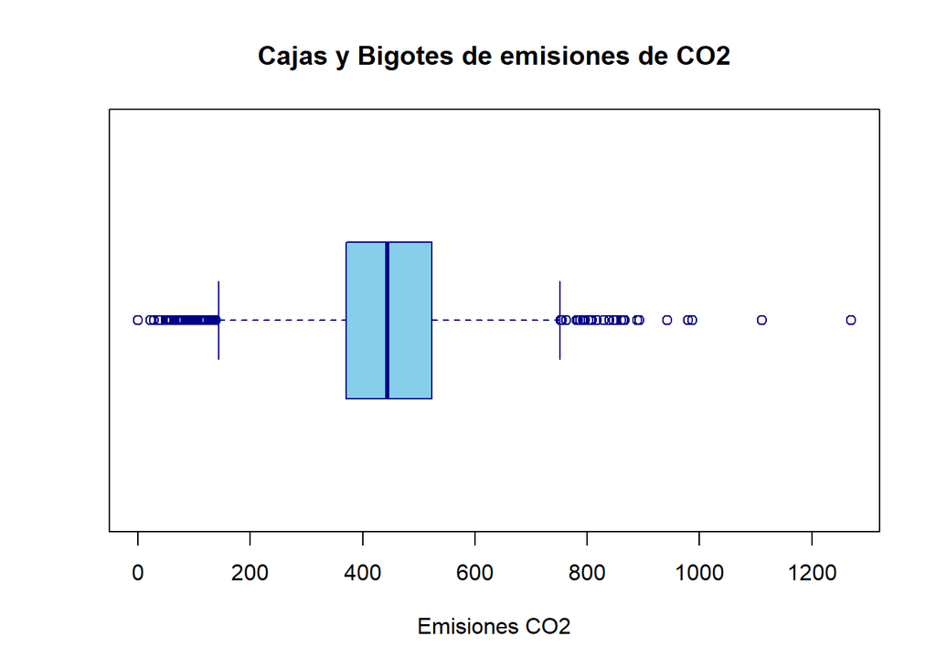

```r
boxplot(
  datos_limpios$co2TailpipeGpm,
  horizontal = TRUE,
  col = "skyblue",
  border = "darkblue",
  main = "Cajas y Bigotes de emisiones de CO2",
  xlab = "Emisiones CO2"
)
```

> El diagrama de caja y bigotes nos muestra la distribución de las emisiones de CO2, destacando una mediana situada aproximadamente en los 450 g/km, con una caja central que concentra el 50% de los datos entre los cuartiles primero y tercero. Es notable la presencia de una gran cantidad de valores atípicos (outliers) tanto por debajo como por encima de los bigotes, lo que indica una variabilidad extensa y la existencia de vehículos con niveles de emisión extremos, especialmente en el extremo superior que llega hasta cerca de los 1,300 g/km. Esta representación confirma que, aunque existe un comportamiento central definido, la dispersión de los datos es significativa y está fuertemente influenciada por modelos que se alejan considerablemente del promedio general.